# **MODEL SMOOTHING TERBAIK**

Joshua Bryan Wijaya~G1401231082

2025-08-31

# **LIBRARY**

```r
library(forecast)
```

```r
library(graphics)
library(TTR)
library(TSA)
library(dplyr)
library(rio)
library(readxl)
library(ggplot2)
```

# **DATA**

```r
data <- read_xlsx("C:/Users/Dell/OneDrive/Desktop/SEMESTER 5/MPDW/Joshua.xlsx")
```

Data yang digunakan adalah data rataan temperatur di Kab. Bogor, dimulai dari rentang waktu 20 Desember 2024 hingga 26 Agustus 2025

# **EKSPLORASI DATA**

```r
data <- data %>% select(date,temp_mean)
View(data)
str(data)
```

```
## tibble [250 × 2] (S3: tbl_df/tbl/data.frame)
##  $ date     : POSIXct[1:250], format: "2024-12-20" "2024-12-21" ...
##  $ temp_mean: num [1:250] 25.9 26.2 25.5 25.6 25 25.3 26.4 26.5 27.2 26.2 ...
```

```r
dim(data)
```

```
## [1] 250   2
```

```r
colSums(is.na(data))
```

```
##      date temp_mean
##         0         2
```

```r
data[!complete.cases(data), ]
```

```
## # A tibble: 2 × 2
##   date                temp_mean
##   <dttm>                  <dbl>
## 1 2025-08-25 00:00:00        NA
## 2 2025-08-26 00:00:00        NA
```

Ditemukan 2 amatan yang null alias tidak memiliki nilai. Selanjutnya, untuk menangani hal ini, akan dilakukan imputasi nilai menggunakan rataan dari seluruh nilai temp_mean.

# **IMPUTASI DATA KOSONG**

```r
mean_val <- mean(data$temp_mean, na.rm = TRUE)
data$temp_mean[is.na(data$temp_mean)] <- mean_val

colSums(is.na(data))
```

```
##      date temp_mean
##         0         0
```

```r
data[!complete.cases(data), ]
```

```
## # A tibble: 0 × 2
## # ℹ 2 variables: date <dttm>, temp_mean <dbl>
```

Setelah dilakukan imputasi data, tidak lagi ditemukan nilai kosong pada data. Imputasi nilai kosong dilakukan dengan menggunakan nilai rataan dari Yt(temperature_mean). Sekarang data sudah siap untuk dianalisis dengan metode smoothing

# **UBAH TIPE DATA**

```r
data.ts <- ts(data$temp_mean)
summary(data.ts)
```

```
##    Min. 1st Qu.  Median    Mean 3rd Qu.    Max.
##   24.00   25.40   25.80   25.81   26.30   27.80
```

# **PLOT DERET WAKTU**

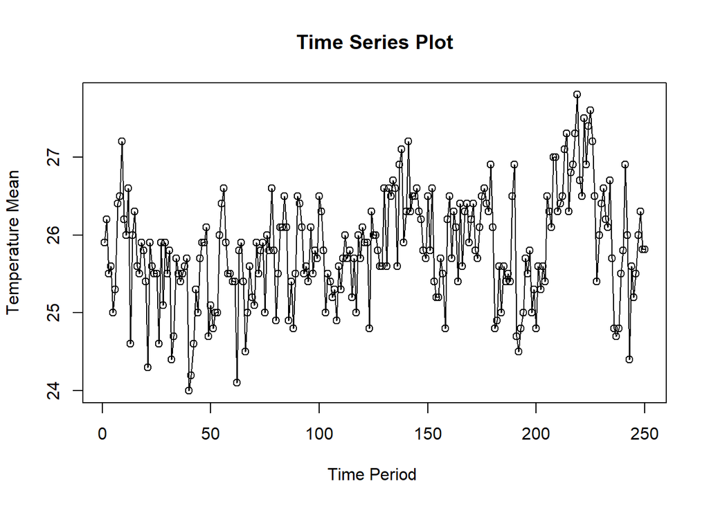

```r
ts.plot(data.ts, xlab="Time Period ", ylab="Temperature Mean",
        main = "Time Series Plot")
points(data.ts)
```

Melalui visualisasi data, terlihat bahwa data temperatur rataan Kab. Bogor cenderung stasioner (rataan dan ragamnya konstan).

# **SINGLE MOVING AVERAGE**

## Data Test x data train

```r
n <- nrow(data)
n_train <- floor(0.8*n)
training_ma <- data[1:n_train,]
testing_ma <- data[(n_train+1):n,]
train_ma.ts<- ts(training_ma$temp_mean)
test_ma.ts<- ts(testing_ma$temp_mean)
```

Data rataan temperatur Kab. Bogor selama 250 hari, kemudian dibagi menjadi data train dan data test dengan perbandingan 80:20. Jumlah data train sebanyak 200 data dan data test sebanyak 50 data.

## Eksplorasi

### Keseluruhan Data

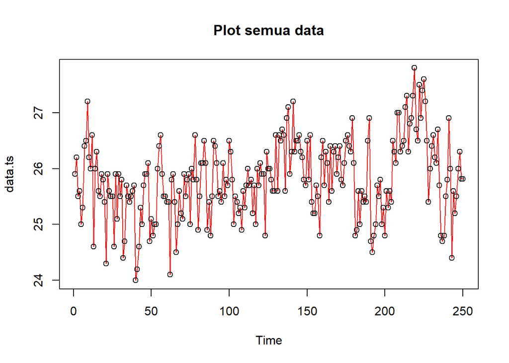

```r
plot(data.ts, col="red",main="Plot semua data")
points(data.ts)
```

### Data Train

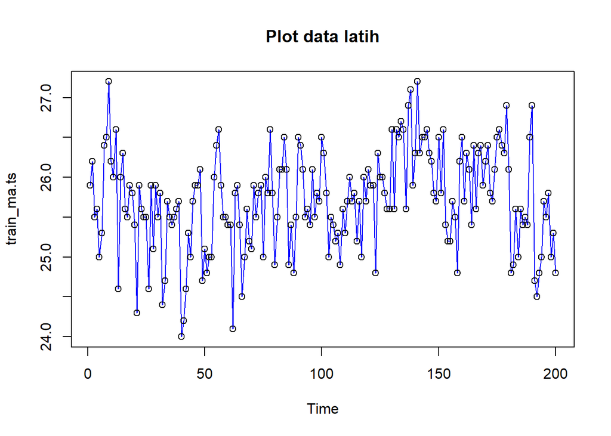

```r
plot(train_ma.ts, col="blue",main="Plot data latih")
points(train_ma.ts)
```

### Data Test

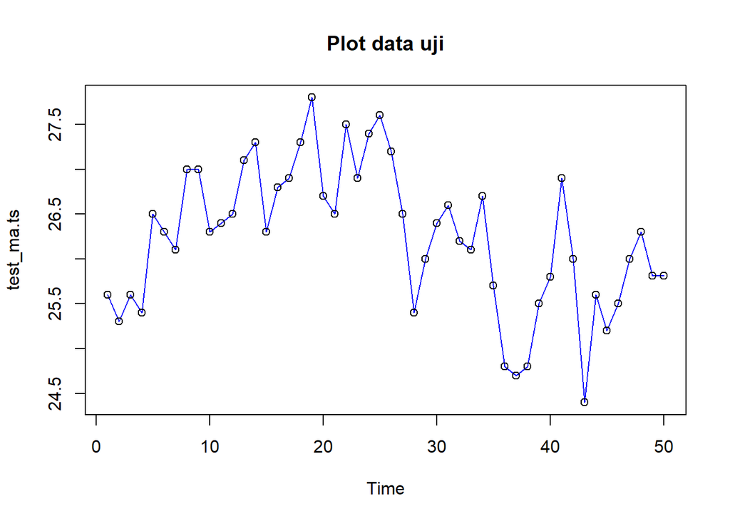

```r
plot(test_ma.ts, col="blue",main="Plot data uji")
points(test_ma.ts)
```

### Utuh Pake Ggplot

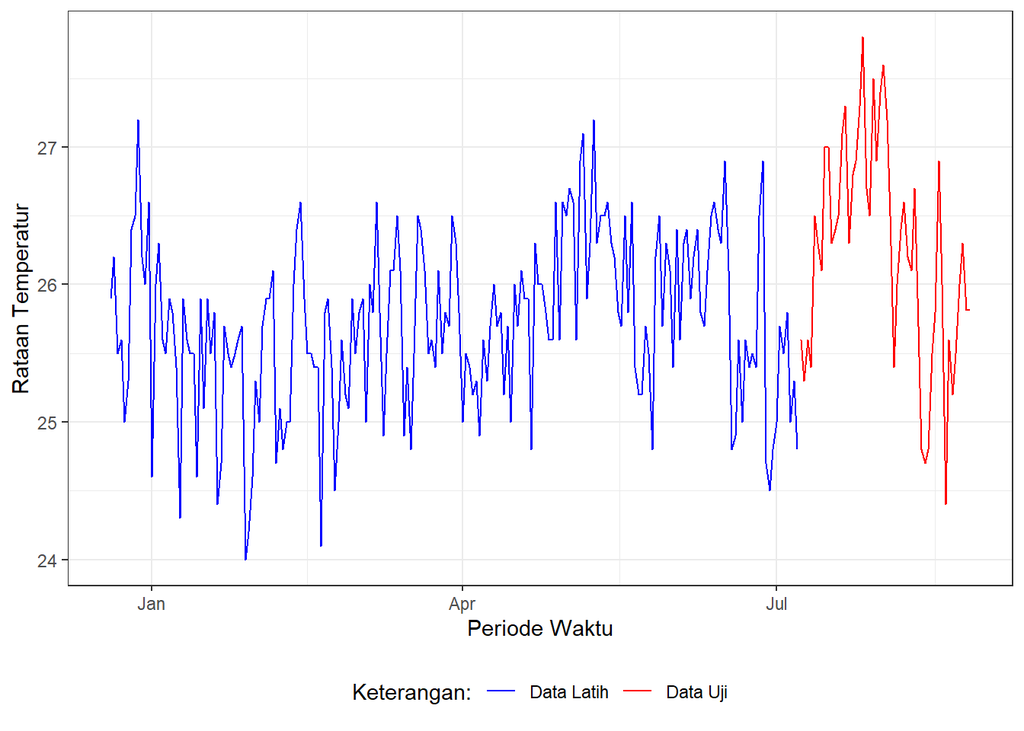

```r
ggplot() +
  geom_line(data = training_ma, aes(x = date, y = temp_mean, col = "Data Latih")) +
  geom_line(data = testing_ma, aes(x = date, y = temp_mean, col = "Data Uji")) +
  labs(x = "Periode Waktu", y = "Rataan Temperatur", color = "Legend") +
  scale_colour_manual(name="Keterangan:", breaks = c("Data Latih", "Data Uji"),
                      values = c("blue", "red")) +
  theme_bw() + theme(legend.position = "bottom",
                     plot.caption = element_text(hjust=0.5, size=12))
```

## Analisis

```r
data.sma<-SMA(train_ma.ts, n=3)
data.sma
```

```
## Time Series:
## Start = 1
## End = 200
## Frequency = 1
##   [1]       NA       NA 25.86667 25.76667 25.36667 25.30000 25.56667 26.06667
##   [9] 26.70000 26.63333 26.46667 26.26667 25.73333 25.73333 25.63333 25.96667
##  [17] 25.80000 25.66667 25.73333 25.70000 25.16667 25.20000 25.26667 25.66667
##  [25] 25.53333 25.20000 25.33333 25.20000 25.63333 25.50000 25.73333 25.23333
##  [33] 24.96667 24.93333 25.30000 25.53333 25.46667 25.50000 25.60000 25.10000
##  [41] 24.63333 24.26667 24.70000 24.96667 25.33333 25.53333 25.83333 25.96667
##  [49] 25.56667 25.30000 24.86667 24.96667 24.93333 25.33333 25.80000 26.33333
##  [57] 26.30000 26.00000 25.63333 25.46667 25.43333 24.96667 25.10000 25.26667
##  [65] 25.70000 25.26667 24.96667 25.03333 25.26667 25.30000 25.40000 25.50000
##  [73] 25.73333 25.73333 25.56667 25.63333 25.60000 26.13333 26.06667 25.76667
##  [81] 25.40000 25.50000 25.90000 26.23333 26.23333 25.83333 25.46667 25.03333
##  [89] 25.23333 25.60000 26.13333 26.33333 26.00000 25.73333 25.50000 25.70000
##  [97] 25.66667 25.80000 25.66667 26.00000 26.16667 26.20000 25.70000 25.43333
## [105] 25.30000 25.36667 25.30000 25.13333 25.26667 25.26667 25.53333 25.66667
## [113] 25.80000 25.83333 25.56667 25.56667 25.30000 25.56667 25.56667 25.93333
## [121] 25.90000 25.96667 25.53333 25.66667 25.70000 26.10000 25.93333 25.80000
## [129] 25.66667 25.93333 25.93333 26.26667 26.23333 26.60000 26.60000 26.30000
## [137] 26.36667 26.53333 26.63333 26.43333 26.46667 26.60000 26.66667 26.43333
## [145] 26.53333 26.46667 26.36667 26.10000 25.90000 26.00000 26.00000 26.30000
## [153] 25.93333 25.73333 25.26667 25.36667 25.46667 25.33333 25.50000 25.83333
## [161] 26.13333 26.16667 26.03333 25.93333 25.96667 25.80000 26.10000 26.10000
## [169] 26.20000 26.16667 26.16667 26.13333 25.96667 25.86667 26.10000 26.40000
## [177] 26.50000 26.43333 26.53333 26.43333 25.93333 25.26667 25.10000 25.16667
## [185] 25.40000 25.33333 25.50000 25.43333 25.80000 26.26667 26.03333 25.36667
## [193] 24.66667 24.76667 25.16667 25.40000 25.66667 25.43333 25.36667 25.03333
```

Dilakukan analisis pemulusan menggunakan metode Single Moving Average. Data pada periode ke-t bergantung pada 3 data periode sebelumnya (m=3). Karena itu data peubah pemulusan pada periode ke-1 dan ke-2 bernilai NA, karena pemulusan pada periode ke-t merupakan rataan dari nilai 3 periode sebelumnya.Ini juga yang menjadi alasan, semakin besar m, visualisasi data akan semakin mulus, namun akan semakin banyak kehilangan data.

```r
data.ramal<-c(NA,data.sma)
data.ramal
```

```
##   [1]       NA       NA       NA 25.86667 25.76667 25.36667 25.30000 25.56667
##   [9] 26.06667 26.70000 26.63333 26.46667 26.26667 25.73333 25.73333 25.63333
##  [17] 25.96667 25.80000 25.66667 25.73333 25.70000 25.16667 25.20000 25.26667
##  [25] 25.66667 25.53333 25.20000 25.33333 25.20000 25.63333 25.50000 25.73333
##  [33] 25.23333 24.96667 24.93333 25.30000 25.53333 25.46667 25.50000 25.60000
##  [41] 25.10000 24.63333 24.26667 24.70000 24.96667 25.33333 25.53333 25.83333
##  [49] 25.96667 25.56667 25.30000 24.86667 24.96667 24.93333 25.33333 25.80000
##  [57] 26.33333 26.30000 26.00000 25.63333 25.46667 25.43333 24.96667 25.10000
##  [65] 25.26667 25.70000 25.26667 24.96667 25.03333 25.26667 25.30000 25.40000
##  [73] 25.50000 25.73333 25.73333 25.56667 25.63333 25.60000 26.13333 26.06667
##  [81] 25.76667 25.40000 25.50000 25.90000 26.23333 26.23333 25.83333 25.46667
##  [89] 25.03333 25.23333 25.60000 26.13333 26.33333 26.00000 25.73333 25.50000
##  [97] 25.70000 25.66667 25.80000 25.66667 26.00000 26.16667 26.20000 25.70000
## [105] 25.43333 25.30000 25.36667 25.30000 25.13333 25.26667 25.26667 25.53333
## [113] 25.66667 25.80000 25.83333 25.56667 25.56667 25.30000 25.56667 25.56667
## [121] 25.93333 25.90000 25.96667 25.53333 25.66667 25.70000 26.10000 25.93333
## [129] 25.80000 25.66667 25.93333 25.93333 26.26667 26.23333 26.60000 26.60000
## [137] 26.30000 26.36667 26.53333 26.63333 26.43333 26.46667 26.60000 26.66667
## [145] 26.43333 26.53333 26.46667 26.36667 26.10000 25.90000 26.00000 26.00000
## [153] 26.30000 25.93333 25.73333 25.26667 25.36667 25.46667 25.33333 25.50000
## [161] 25.83333 26.13333 26.16667 26.03333 25.93333 25.96667 25.80000 26.10000
## [169] 26.10000 26.20000 26.16667 26.16667 26.13333 25.96667 25.86667 26.10000
## [177] 26.40000 26.50000 26.43333 26.53333 26.43333 25.93333 25.26667 25.10000
## [185] 25.16667 25.40000 25.33333 25.50000 25.43333 25.80000 26.26667 26.03333
## [193] 25.36667 24.66667 24.76667 25.16667 25.40000 25.66667 25.43333 25.36667
## [201] 25.03333
```

Selanjutnya, untuk menentukan peramalan, hanya cukup menambahkan 1 baris NA pada data pemulusan. Karena nilai smoothing pada periode ke-t berperan sebagai nilai forecasting untuk periode ke- (t+1)

## Peramalan Data Latih

```r
data.gab<-cbind(
  aktual=c(data.ts),
  pemulusan=c(data.sma,rep(NA,50)),
  ramalan=c(data.ramal,rep(data.ramal[length(data.ramal)],49)))

data.gab
```

```
##         aktual pemulusan  ramalan
##   [1,] 25.9000        NA       NA
##   [2,] 26.2000        NA       NA
##   [3,] 25.5000  25.86667       NA
##   [4,] 25.6000  25.76667 25.86667
##   [5,] 25.0000  25.36667 25.76667
##   [6,] 25.3000  25.30000 25.36667
##   [7,] 26.4000  25.56667 25.30000
##   [8,] 26.5000  26.06667 25.56667
##   [9,] 27.2000  26.70000 26.06667
##  [10,] 26.2000  26.63333 26.70000
##  [11,] 26.0000  26.46667 26.63333
##  [12,] 26.6000  26.26667 26.46667
##  [13,] 24.6000  25.73333 26.26667
##  [14,] 26.0000  25.73333 25.73333
```

[output cut: 236 more lines]

## Visualisasi

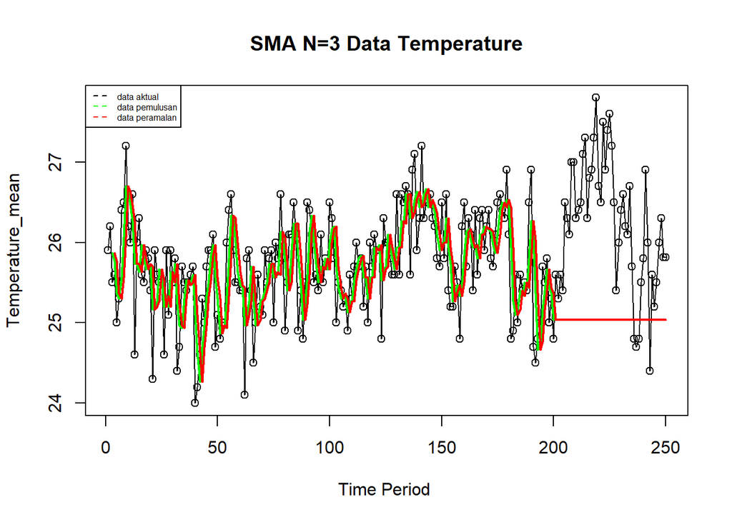

```r
ts.plot(data.ts, xlab="Time Period ", ylab="Temperature_mean", main= "SMA N=3 Data Temperature")
points(data.ts)
lines(data.gab[,2],col="green",lwd=2)
lines(data.gab[,3],col="red",lwd=2)
legend("topleft",c("data aktual","data pemulusan","data peramalan"), lty=8, col=c("black","green","red"), cex=0.5)
```

Disini dapat terlihat bahwa ramalan untuk periode di luar jangkauan pemulusan, akan bernilai pengulangan dari data pemulusan periode terakhir (Nilainya akan sama terus == konstan). Oleh karena itu, metode single moving average ini lebih cocok digunakan untuk data yang relatif konstan atau stasioner. Metode forecasting menggunakan Moving Average tidak memberikan pembobotan berbeda pada periode terbaru atau terlama.

## Akurasi

### Akurasi Data Latih

```r
error_train.sma = train_ma.ts-data.ramal[1:length(train_ma.ts)]

SSE_train.sma = sum(error_train.sma[4:length(train_ma.ts)]^2)
MSE_train.sma = mean(error_train.sma[4:length(train_ma.ts)]^2)
MAPE_train.sma = mean(abs((error_train.sma[4:length(train_ma.ts)]/train_ma.ts[4:length(train_ma.ts)])*100))

akurasi_train.sma <- matrix(c(SSE_train.sma, MSE_train.sma, MAPE_train.sma))
row.names(akurasi_train.sma)<- c("SSE", "MSE", "MAPE")
colnames(akurasi_train.sma) <- c("Akurasi m = 3")
akurasi_train.sma
```

```
##      Akurasi m = 3
## SSE     77.6644444
## MSE      0.3942358
## MAPE     1.9444344
```

Yang perlu diconsider pertama adalah data residual yang digunakan untuk menghitung error dimulai dari periode 4 hingga 200 (panjang data train). Hal ini disebabkan, data forecasting pada model baru bernilai ≠ NA ketika periode ke-4 hingga periode ke-n dari data latih

- $SSE$ sendiri merupakan selisih kuadrat dari data latih aktual dengan data yang diperoleh lewat pemulusan. SSE sebesar 77.66 dapat dikatakan sudah rendah, apabila dibandingkan dengan skala aktual data (rataan temperatur suhu)
- $MSE$ merupakan kuadrat tengah dari galat, alias nilai SSE dibagi derajat bebas galat (rataan jumlah kuadrat galat). Nilai MSE sebesar 0.39 mengindikasikan bahwa data forecasting menggunakan SMA sudah mendekati data aktualnya (pada data latih)
- $MAPE$ menunjukkan rataan kesalahan prediksi dalam bentuk persen. Nilai rataan kesalahan prediksi dari 200 data latih hanya bernilai 1.94%,masih <10%. Ini mengindikasikan bahwa nilai forecast terhadap data aktual sudah sangat baik.

### Akurasi Data Uji

```r
error_test.sma = test_ma.ts-data.gab[201:250,3]

SSE_test.sma = sum(error_test.sma^2)
MSE_test.sma = mean(error_test.sma^2)
MAPE_test.sma = mean(abs((error_test.sma/test_ma.ts*100)))

akurasi_test.sma <- matrix(c(SSE_test.sma, MSE_test.sma, MAPE_test.sma))
row.names(akurasi_test.sma)<- c("SSE", "MSE", "MAPE")
colnames(akurasi_test.sma) <- c("Akurasi m = 3")
akurasi_test.sma
```

```
##      Akurasi m = 3
## SSE     104.322125
## MSE       2.086443
## MAPE      4.745624
```

Yang perlu diconsider pertama adalah data residual yang digunakan untuk menghitung error dimulai dari periode 201 hingga 250 (panjang data uji). Ya sesimpel karena data forecast dan data aktual yang akan dibandingkan adalah data test

- $SSE$ sendiri merupakan selisih kuadrat dari data latih aktual dengan data yang diperoleh lewat pemulusan. SSE sebesar 104.32 masih dapat dikatakan rendah, apabila dibandingkan dengan skala aktual data (rataan temperatur suhu).
- $MSE$ merupakan kuadrat tengah dari galat, alias nilai SSE dibagi derajat bebas galat (rataan jumlah kuadrat galat). Nilai MSE sebesar 2.08 mengindikasikan bahwa data forecasting menggunakan SMA sudah mendekati data aktualnya (pada data uji).
- $MAPE$ menunjukkan rataan kesalahan prediksi dalam bentuk persen. Nilai rataan kesalahan prediksi dari 50 data latih hanya bernilai 4.75%, masih <10%. Ini mengindikasikan bahwa nilai forecast terhadap data aktual sudah sangat baik, karena rataan kesalahannya hanya sekitar 4%.

# **DOUBLE MOVING AVERAGE**

```r
dma <- SMA(data.sma, n = 3)
At <- 2*data.sma - dma
Bt <- 2/(3-1)*(data.sma - dma)
data.dma<- At+Bt
data.ramal2<- c(NA, data.dma)

t = 1:50
f = c()

for (i in t) {
  f[i] = At[length(At)] + Bt[length(Bt)]*(i)
}

data.gab2 <- cbind(aktual = c(data.ts),
                   pemulusan1 = c(data.sma,rep(NA,50)),
                   pemulusan2 = c(dma, rep(NA,50)),
                   At = c(At, rep(NA,50)),
                   Bt = c(Bt,rep(NA,50)),
                   ramalan = c(data.ramal2, f[-1]))
data.gab2
```

```
##         aktual pemulusan1 pemulusan2       At            Bt  ramalan
##   [1,] 25.9000         NA         NA       NA            NA       NA
##   [2,] 26.2000         NA         NA       NA            NA       NA
##   [3,] 25.5000   25.86667         NA       NA            NA       NA
##   [4,] 25.6000   25.76667         NA       NA            NA       NA
##   [5,] 25.0000   25.36667   25.66667 25.06667 -3.000000e-01       NA
##   [6,] 25.3000   25.30000   25.47778 25.12222 -1.777778e-01 24.76667
##   [7,] 26.4000   25.56667   25.41111 25.72222  1.555556e-01 24.94444
##   [8,] 26.5000   26.06667   25.64444 26.48889  4.222222e-01 25.87778
##   [9,] 27.2000   26.70000   26.11111 27.28889  5.888889e-01 26.91111
##  [10,] 26.2000   26.63333   26.46667 26.80000  1.666667e-01 27.87778
##  [11,] 26.0000   26.46667   26.60000 26.33333 -1.333333e-01 26.96667
##  [12,] 26.6000   26.26667   26.45556 26.07778 -1.888889e-01 26.20000
##  [13,] 24.6000   25.73333   26.15556 25.31111 -4.222222e-01 25.88889
##  [14,] 26.0000   25.73333   25.91111 25.55556 -1.777778e-01 24.88889
```

[output cut: 236 more lines]

Masih sama seperti sebelumnya, digunakan m=3, artinya pemulusan data pada periode ke-t bergantung pada rataan dari 3 periode data sebelumnya. Karena dilakukan dua kali pemulusan, data yang hilang akan semakin banyak, karenanya data forecastingnya baru ≠ 0 sejak periode 6 hingga periode ke-n dati data.

## Visualisasi

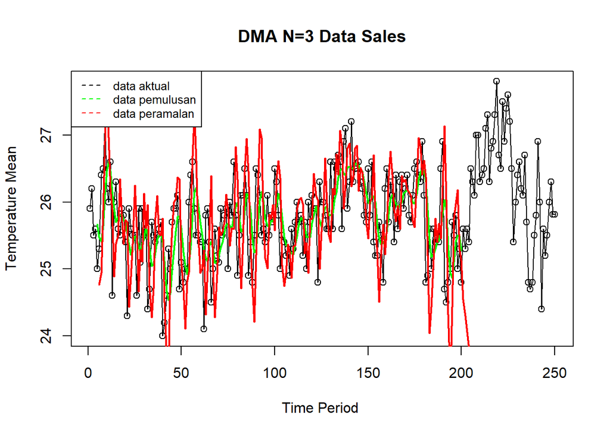

```r
ts.plot(data.ts, xlab="Time Period ", ylab="Temperature Mean", main= "DMA N=3 Data Sales")
points(data.ts)
lines(data.gab2[,3],col="green",lwd=2)
lines(data.gab2[,6],col="red",lwd=2)
legend("topleft",c("data aktual","data pemulusan","data peramalan"), lty=8, col=c("black","green","red"), cex=0.8)
```

Double Moving Average cocok digunakan hanya untuk data berupa trend. Dari eksplorasi di awal, dapat diketahui bahwa plot data rataan temperatur Kab. Bogor cenderung menyebar konstan atau stasioner. Karenanya, apabila dilakukan forecasting menggunakan DMA, data forecast cenderung menyimpang dari data aktualnya. Pada visualisasi ini, dapat terlihat bahwa data forecast menunjukkan seakan data memiliki trend turun. Apalagi data forecast diestimasi menggunakan rumus At + Bt(h), yang mana pengali h akan terus meningkat untuk meramalkan data periode ke-t yang berada di luar area pemulusan kedua. Itu sebabnya, tanda Bt pada akhir pemulusan kedua sangat berpengaruh pada peramalan data kedepannya

## Akurasi

### Akurasi Data Latih

```r
error_train.dma = train_ma.ts-data.ramal2[1:length(train_ma.ts)]

SSE_train.dma = sum(error_train.dma[6:length(train_ma.ts)]^2)
MSE_train.dma = mean(error_train.dma[6:length(train_ma.ts)]^2)
MAPE_train.dma = mean(abs((error_train.dma[6:length(train_ma.ts)]/train_ma.ts[6:length(train_ma.ts)])*100))

akurasi_train.dma <- matrix(c(SSE_train.dma, MSE_train.dma, MAPE_train.dma))
row.names(akurasi_train.dma)<- c("SSE", "MSE", "MAPE")
colnames(akurasi_train.dma) <- c("Akurasi m = 3")
akurasi_train.dma
```

```
##      Akurasi m = 3
## SSE    125.3709877
## MSE      0.6429281
## MAPE     2.4537257
```

Yang perlu diconsider pertama adalah data residual yang digunakan untuk menghitung error dimulai dari periode 6 hingga 200 (panjang data latih). Hal ini disebabkan, data forecasting pada model baru bernilai ≠ NA ketika periode ke-6 hingga periode ke-n dari data latih

- $SSE$ sendiri merupakan selisih kuadrat dari data latih aktual dengan data yang diperoleh lewat pemulusan. SSE sebesar 125.37 masih dapat dikatakan rendah, apabila dibandingkan dengan skala aktual data (rataan temperatur suhu)
- $MSE$ merupakan kuadrat tengah dari galat, alias nilai SSE dibagi derajat bebas galat (rataan jumlah kuadrat galat). Nilai MSE sebesar 0.64 mengindikasikan bahwa data forecasting menggunakan DMA sudah mendekati data aktualnya (pada data latih)
- $MAPE$ menunjukkan rataan kesalahan prediksi dalam bentuk persen. Nilai rataan kesalahan prediksi dari 200 data latih hanya bernilai 2.45%, yang mana <10%. Ini mengindikasikan bahwa nilai forecast terhadap data aktual sudah sangat baik.

### Akurasi Data Uji

```r
error_test.dma = test_ma.ts-data.gab2[201:250,6]
SSE_test.dma = sum(error_test.dma^2)
MSE_test.dma = mean(error_test.dma^2)
MAPE_test.dma = mean(abs((error_test.dma/test_ma.ts*100)))

akurasi_test.dma <- matrix(c(SSE_test.dma, MSE_test.dma, MAPE_test.dma))
row.names(akurasi_test.dma)<- c("SSE", "MSE", "MAPE")
colnames(akurasi_test.dma) <- c("Akurasi m = 3")
akurasi_test.dma
```

```
##      Akurasi m = 3
## SSE     3509.92370
## MSE       70.19847
## MAPE      29.36399
```

Yang perlu diconsider pertama adalah data residual yang digunakan untuk menghitung error dimulai dari periode 201 hingga 250 (panjang data uji). Ya sesimpel karena data forecast dan data aktual yang akan dibandingkan adalah data test

- $SSE$ sendiri merupakan selisih kuadrat dari data latih aktual dengan data yang diperoleh lewat pemulusan. SSE sebesar 3509.92 dapat dikatakan bernilai besar apabila dibandingkan dengan skala aktual data (rataan temperatur suhu).
- $MSE$ merupakan kuadrat tengah dari galat, alias nilai SSE dibagi derajat bebas galat (rataan jumlah kuadrat galat). Nilai MSE sebesar 70.2 mengindikasikan bahwa data forecasting menggunakan DMA mulai melenceng data aktualnya (pada data uji).
- $MAPE$ menunjukkan rataan kesalahan prediksi dalam bentuk persen. Nilai rataan kesalahan prediksi dari 50 data latih bernilai 29.36%, yang mana sudah >10%. Ini mengindikasikan bahwa nilai forecast rata-rata meleset 29.36% dari data aktual (data uji). Jika dibandingkan dengan MAPE pada forecast data latih, perbedaannya terlalu signifikan hingga dapat dikatakan model mengalami overfitting.

# **SINGLE EXPONENTIAL SMOOTHING**

## Pembagian Data

```r
n <- nrow(data)
n_train <- floor(0.8 * n)
training <- data[1:n_train, ]
testing  <- data[(n_train+1):n, ]
train.ts <- ts(training$temp_mean)
test.ts  <- ts(testing$temp_mean)
```

Masih sama seperti sebelumnya, data rataan temperatur Kab. Bogor selama 250 hari, kemudian dibagi menjadi data train dan data test dengan perbandingan 80:20. Jumlah data train sebanyak 200 data dan data test sebanyak 50 data.

## Eksplorasi

### Data Utuh

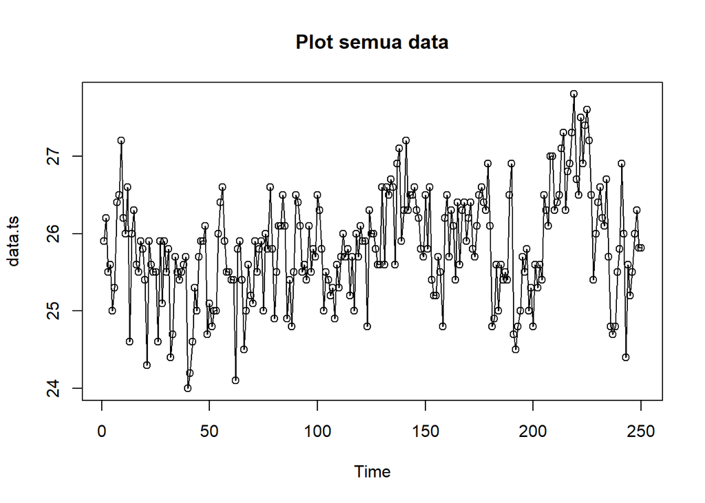

```r
plot(data.ts, col="black",main="Plot semua data")
points(data.ts)
```

### Data Latih

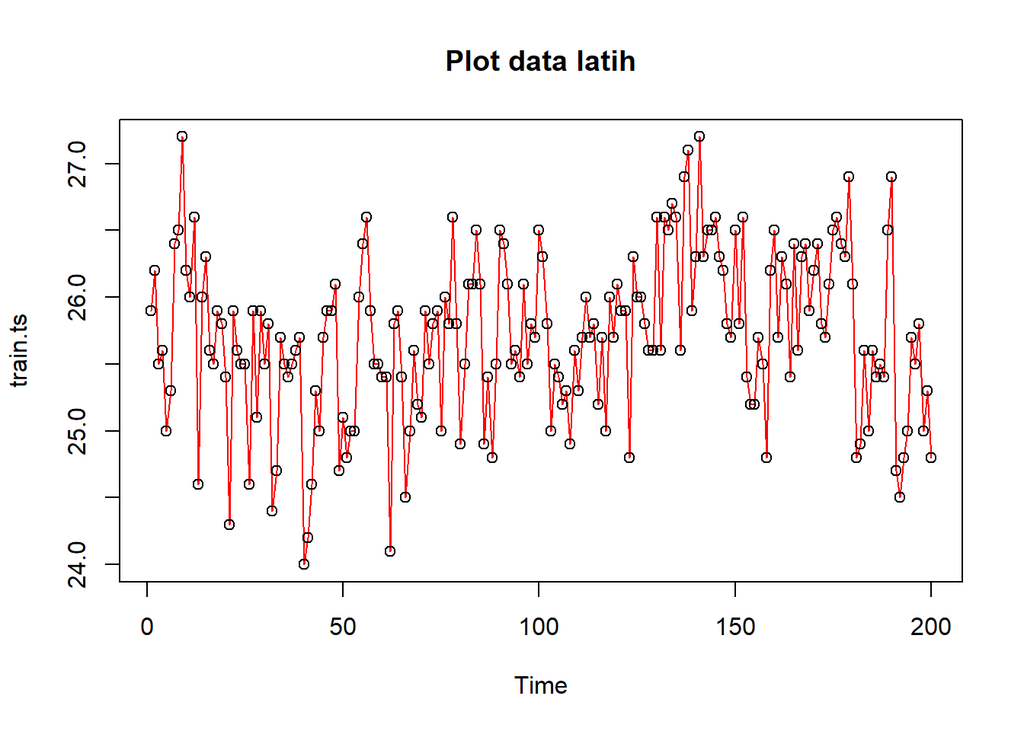

```r
plot(train.ts, col="red",main="Plot data latih")
points(train.ts)
```

### Data Uji

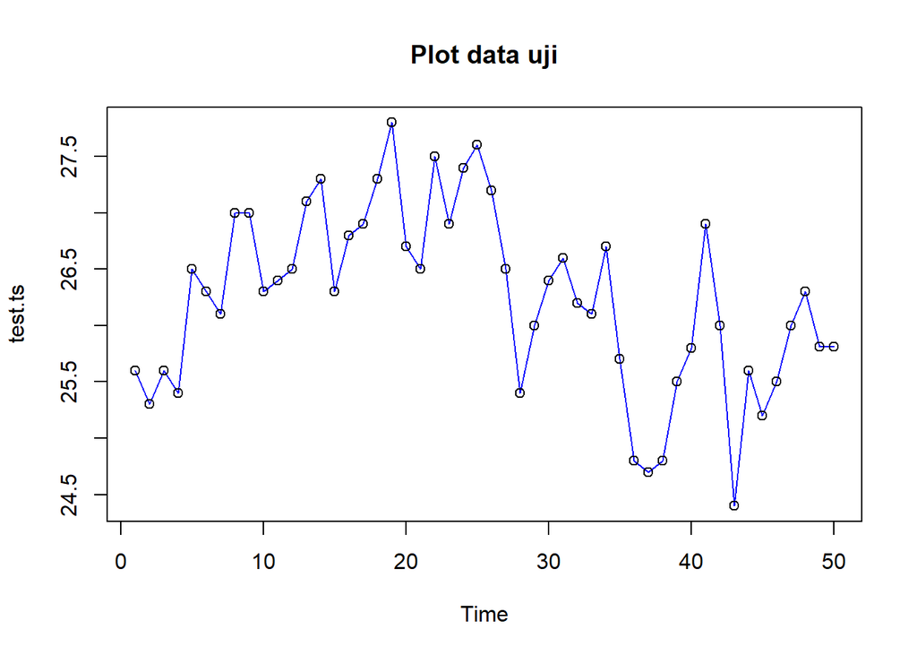

```r
plot(test.ts, col="blue",main="Plot data uji")
points(test.ts)
```

### Utuh Pake Ggplot

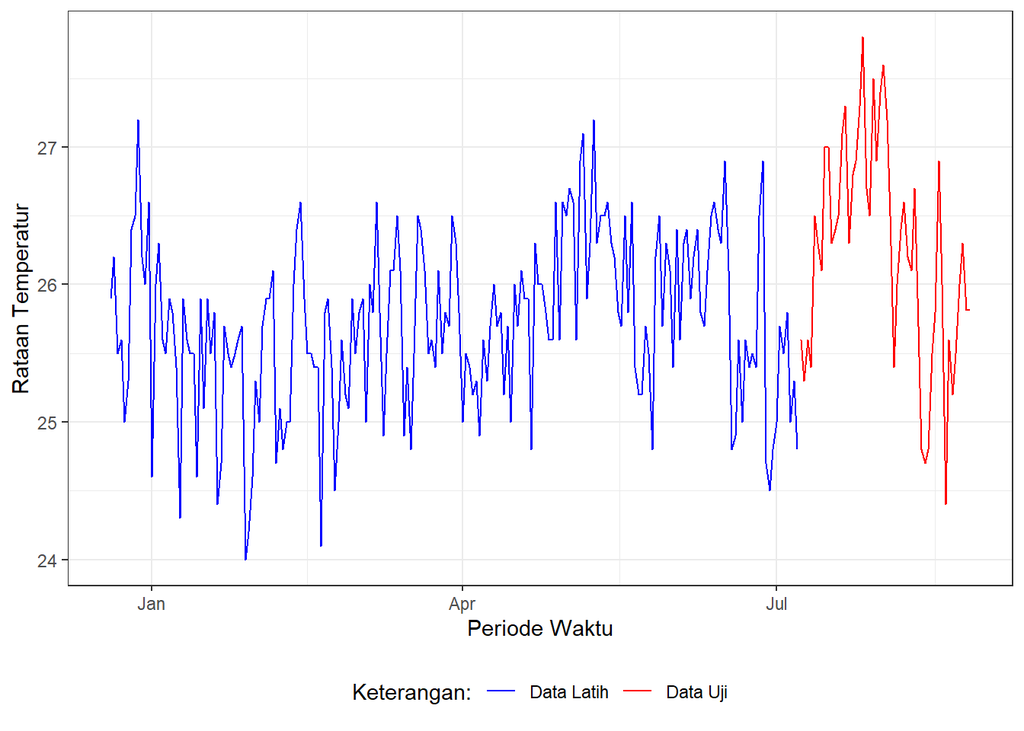

```r
ggplot() +
  geom_line(data = training, aes(x = date, y = temp_mean, col = "Data Latih")) +
  geom_line(data = testing, aes(x = date, y = temp_mean, col = "Data Uji")) +
  labs(x = "Periode Waktu", y = "Rataan Temperatur", color = "Legend") +
  scale_colour_manual(name="Keterangan:", breaks = c("Data Latih", "Data Uji"),
                      values = c("blue", "red")) +
  theme_bw() + theme(legend.position = "bottom",
                     plot.caption = element_text(hjust=0.5, size=12))
```

## Analisis

### Cara 1 : Fungsi SES

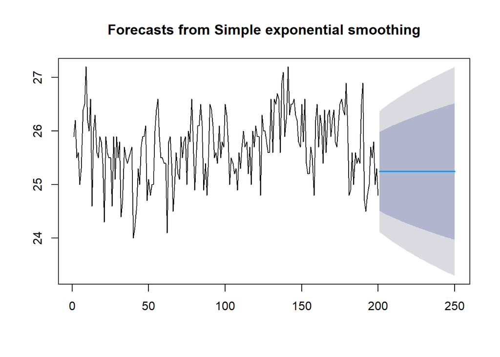

```r
ses.1 <- ses(train.ts, h = 50, alpha = 0.2)
plot(ses.1)
```

```r
ses.1
```

```
##     Point Forecast    Lo 80    Hi 80    Lo 95    Hi 95
## 201       25.24592 24.50573 25.98611 24.11389 26.37794
## 202       25.24592 24.49107 26.00077 24.09148 26.40036
## 203       25.24592 24.47669 26.01515 24.06948 26.42235
## 204       25.24592 24.46257 26.02926 24.04790 26.44394
## 205       25.24592 24.44871 26.04313 24.02669 26.46515
## 206       25.24592 24.43508 26.05676 24.00585 26.48599
## 207       25.24592 24.42168 26.07016 23.98535 26.50649
## 208       25.24592 24.40849 26.08335 23.96518 26.52666
## 209       25.24592 24.39550 26.09633 23.94532 26.54652
## 210       25.24592 24.38271 26.10912 23.92576 26.56608
## 211       25.24592 24.37011 26.12173 23.90649 26.58535
## 212       25.24592 24.35769 26.13415 23.88749 26.60435
## 213       25.24592 24.34544 26.14640 23.86875 26.62309
## 214       25.24592 24.33335 26.15849 23.85026 26.64157
```

[output cut: 36 more lines]

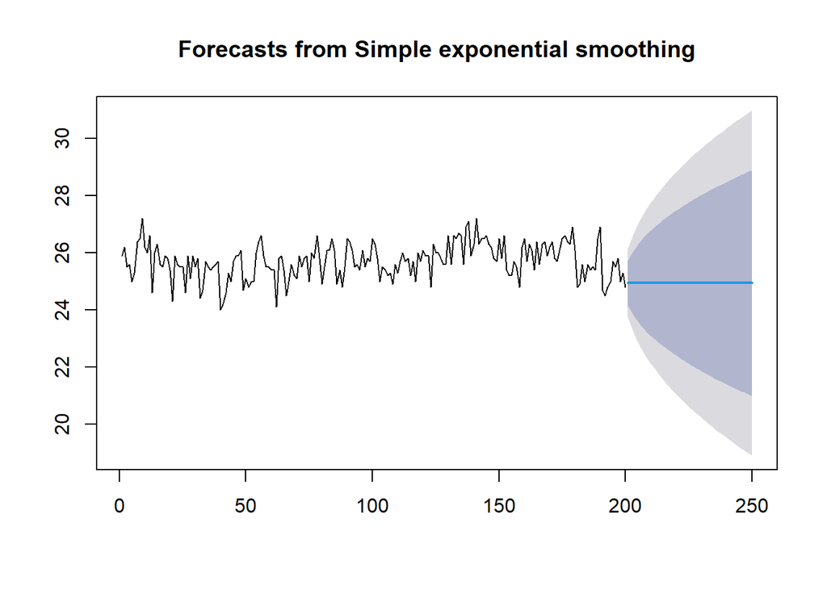

```r
ses.2<- ses(train.ts, h = 50, alpha = 0.7)
plot(ses.2)
```

```r
ses.2
```

```
##     Point Forecast    Lo 80    Hi 80    Lo 95    Hi 95
## 201        24.9421 24.15164 25.73256 23.73319 26.15100
## 202        24.9421 23.97722 25.90698 23.46644 26.41775
## 203        24.9421 23.82982 26.05437 23.24102 26.64318
## 204        24.9421 23.69979 26.18440 23.04216 26.84204
## 205        24.9421 23.58214 26.30206 22.86222 27.02198
## 206        24.9421 23.47388 26.41031 22.69666 27.18754
## 207        24.9421 23.37308 26.51112 22.54249 27.34170
## 208        24.9421 23.27837 26.60582 22.39765 27.48655
## 209        24.9421 23.18877 26.69542 22.26062 27.62358
## 210        24.9421 23.10354 26.78066 22.13026 27.75394
## 211        24.9421 23.02208 26.86212 22.00568 27.87852
## 212        24.9421 22.94394 26.94026 21.88618 27.99802
## 213        24.9421 22.86874 27.01545 21.77117 28.11302
## 214        24.9421 22.79618 27.08802 21.66020 28.22400
```

[output cut: 36 more lines]

### Cara 2 : Holtwinter

#### Alpha ditentukan

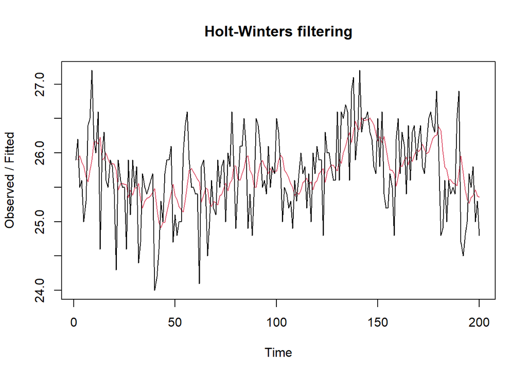

```r
ses1<- HoltWinters(train.ts, gamma = FALSE, beta = FALSE, alpha = 0.2)
plot(ses1)
```

```r
ramalan1<- forecast(ses1, h=50)
ramalan1
```

```
##     Point Forecast    Lo 80    Hi 80    Lo 95    Hi 95
## 201       25.24592 24.50598 25.98586 24.11428 26.37756
## 202       25.24592 24.49133 26.00051 24.09187 26.39997
## 203       25.24592 24.47695 26.01489 24.06988 26.42195
## 204       25.24592 24.46284 26.02900 24.04830 26.44353
## 205       25.24592 24.44898 26.04286 24.02710 26.46473
## 206       25.24592 24.43536 26.05648 24.00627 26.48557
## 207       25.24592 24.42196 26.06988 23.98578 26.50606
## 208       25.24592 24.40877 26.08307 23.96561 26.52622
## 209       25.24592 24.39579 26.09605 23.94576 26.54607
## 210       25.24592 24.38301 26.10883 23.92621 26.56563
## 211       25.24592 24.37041 26.12143 23.90694 26.58489
## 212       25.24592 24.35799 26.13385 23.88795 26.60389
## 213       25.24592 24.34574 26.14609 23.86922 26.62262
## 214       25.24592 24.33366 26.15818 23.85074 26.64110
```

[output cut: 36 more lines]

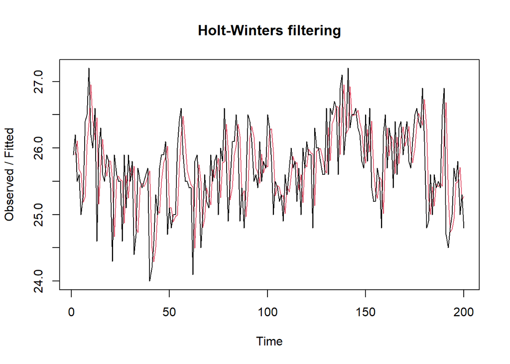

```r
ses2<- HoltWinters(train.ts, gamma = FALSE, beta = FALSE, alpha = 0.7)
plot(ses2)
```

```r
ramalan2<- forecast(ses2, h=50)
ramalan2
```

```
##     Point Forecast    Lo 80    Hi 80    Lo 95    Hi 95
## 201        24.9421 24.15168 25.73251 23.73326 26.15093
## 202        24.9421 23.97727 25.90692 23.46653 26.41767
## 203        24.9421 23.82989 26.05431 23.24112 26.64308
## 204        24.9421 23.69986 26.18433 23.04227 26.84193
## 205        24.9421 23.58222 26.30198 22.86234 27.02186
## 206        24.9421 23.47397 26.41023 22.69679 27.18741
## 207        24.9421 23.37317 26.51103 22.54263 27.34157
## 208        24.9421 23.27847 26.60573 22.39780 27.48640
## 209        24.9421 23.18887 26.69532 22.26077 27.62342
## 210        24.9421 23.10364 26.78056 22.13042 27.75378
## 211        24.9421 23.02219 26.86201 22.00585 27.87835
## 212        24.9421 22.94405 26.94014 21.88635 27.99784
## 213        24.9421 22.86886 27.01534 21.77135 28.11284
## 214        24.9421 22.79630 27.08790 21.66038 28.22381
```

[output cut: 36 more lines]

#### Alpha optimal

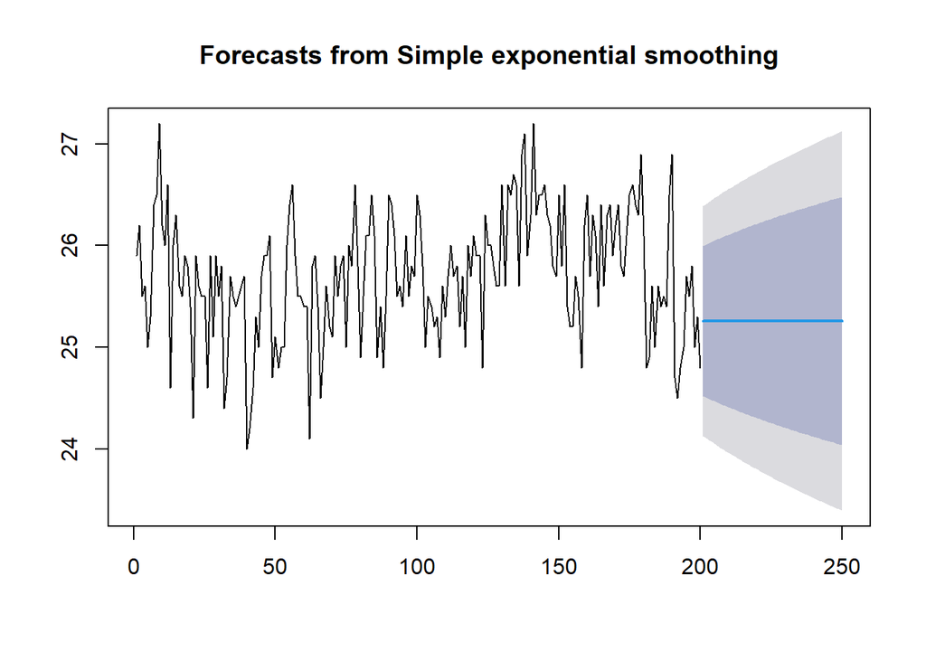

```r
ses.opt <- ses(train.ts, h = 50, alpha = NULL)
plot(ses.opt)
```

```r
ses.opt
```

```
##     Point Forecast    Lo 80    Hi 80    Lo 95    Hi 95
## 201       25.25873 24.51863 25.99882 24.12685 26.39061
## 202       25.25873 24.50576 26.01169 24.10716 26.41029
## 203       25.25873 24.49311 26.02435 24.08781 26.42964
## 204       25.25873 24.48066 26.03679 24.06878 26.44868
## 205       25.25873 24.46841 26.04904 24.05004 26.46741
## 206       25.25873 24.45635 26.06111 24.03159 26.48586
## 207       25.25873 24.44446 26.07299 24.01341 26.50404
## 208       25.25873 24.43275 26.08471 23.99550 26.52196
## 209       25.25873 24.42119 26.09626 23.97783 26.53962
## 210       25.25873 24.40980 26.10765 23.96041 26.55705
## 211       25.25873 24.39856 26.11890 23.94321 26.57424
## 212       25.25873 24.38746 26.12999 23.92624 26.59121
## 213       25.25873 24.37650 26.14095 23.90948 26.60797
## 214       25.25873 24.36568 26.15177 23.89293 26.62453
```

[output cut: 36 more lines]

```r
HWopt<- HoltWinters(train.ts, gamma = FALSE, beta = FALSE,alpha = NULL)
HWopt
```

```
## Holt-Winters exponential smoothing without trend and without seasonal component.
##
## Call:
## HoltWinters(x = train.ts, alpha = NULL, beta = FALSE, gamma = FALSE)
##
## Smoothing parameters:
##  alpha: 0.1873665
##  beta : FALSE
##  gamma: FALSE
##
## Coefficients:
##       [,1]
## a 25.25865
```

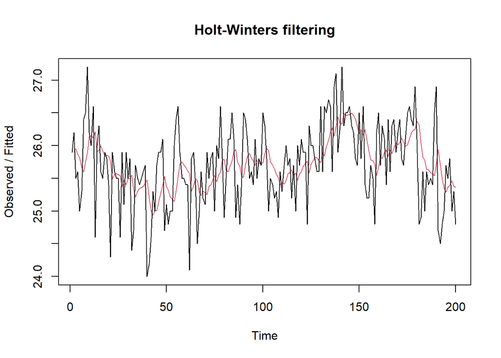

```r
plot(HWopt)
```

```r
ramalanopt<- forecast(HWopt, h=50)
ramalanopt
```

```
##     Point Forecast    Lo 80    Hi 80    Lo 95    Hi 95
## 201       25.25865 24.51883 25.99847 24.12720 26.39011
## 202       25.25865 24.50596 26.01134 24.10751 26.40979
## 203       25.25865 24.49330 26.02400 24.08815 26.42915
## 204       25.25865 24.48085 26.03645 24.06911 26.44820
## 205       25.25865 24.46860 26.04871 24.05037 26.46694
## 206       25.25865 24.45653 26.06078 24.03191 26.48540
## 207       25.25865 24.44464 26.07267 24.01373 26.50358
## 208       25.25865 24.43292 26.08438 23.99580 26.52150
## 209       25.25865 24.42137 26.09594 23.97813 26.53917
## 210       25.25865 24.40997 26.10733 23.96070 26.55660
## 211       25.25865 24.39872 26.11858 23.94350 26.57380
## 212       25.25865 24.38762 26.12968 23.92653 26.59078
## 213       25.25865 24.37666 26.14064 23.90976 26.60754
## 214       25.25865 24.36584 26.15147 23.89321 26.62410
```

[output cut: 36 more lines]

Menggunakan fungsi HWopt, ditemukan alpha atau lambda optimal (bobot optimal) untuk data terbaru adalah sebesar 0.19. Selanjutnya model dengan lambda optimal ini akan diuji akurasinya jika dibandingkan ketika menggunakan alpha = 0.2 dan alpha = 0.7

## Akurasi

### Akurasi Data Latih

```r
SSE1<-ses1$SSE
MSE1<-ses1$SSE/length(train.ts)
RMSE1<-sqrt(MSE1)
MAPE1 <- mean(abs(ses.1$residuals/train.ts))*100

akurasi1 <- matrix(c(SSE1,MSE1,RMSE1,MAPE1))
row.names(akurasi1)<- c("SSE", "MSE", "RMSE", "MAPE")
colnames(akurasi1) <- c("Akurasi lamda=0.2")
akurasi1
```

```
##      Akurasi lamda=0.2
## SSE         66.0601114
## MSE          0.3303006
## RMSE         0.5747178
## MAPE         1.7911005
```

```r
SSE2<-ses2$SSE
MSE2<-ses2$SSE/length(train.ts)
RMSE2<-sqrt(MSE2)
MAPE2 <- mean(abs(ses.2$residuals/train.ts))*100

akurasi2 <- matrix(c(SSE2,MSE2,RMSE2, MAPE2))
row.names(akurasi2)<- c("SSE", "MSE", "RMSE", "MAPE")
colnames(akurasi2) <- c("Akurasi lamda=0.7")
akurasi2
```

```
##      Akurasi lamda=0.7
## SSE         75.3281200
## MSE          0.3766406
## RMSE         0.6137105
## MAPE         1.8424820
```

- $SSE$ merupakan selisih kuadrat dari data latih aktual dengan data yang diperoleh lewat pemulusan. SSE sebesar 66.06 dan 75.33 dapat dikatakan bernilai rendah apabila dibandingkan dengan skala aktual data (rataan temperatur suhu).Dapat terlihat bahwa SSE pada $\alpha$ = 0.2 lebih kecil dibanding $\alpha$ = 0.7
- $MSE$ merupakan kuadrat tengah dari galat, alias nilai SSE dibagi derajat bebas galat (rataan jumlah kuadrat galat). Nilai MSE sebesar 0.33 dan 0.38 mengindikasikan bahwa data forecasting menggunakan SES cenderung dekat dengan data aktualnya (pada data latih). Dapat terlihat bahwa MSE pada $\alpha$ = 0.2 lebih kecil dibanding $\alpha$ = 0.7
- $RMSE$ merupakan akar dari MSE, dengan satuan data asli dan pembobotan lebih besar pada error yang tinggi. RMSE sebesar 0.61 mengindikasikan bahwa data forecasting menggunakna SES sudah dekat dengan nilai aktualnya (data latih).
- $MAPE$ menunjukkan rataan kesalahan prediksi dalam bentuk persen. Nilai rataan kesalahan prediksi dari 200 data latih hanya bernilai 1.79% untuk $\alpha$ = 0.2 dan 1.84% untuk $\alpha$ = 0.7,masih <10%. Ini mengindikasikan bahwa nilai forecast terhadap data aktual sudah sangat baik. Akan tetapi, MAPE pada $\alpha$= 0.2 lebih kecil dibanding MAPE pada $\alpha$ = 0.7

### Akurasi Data Uji

```r
n_test <- nrow(testing)

e1   <- as.numeric(ramalan1$mean)[1:n_test] - as.numeric(testing$temp_mean)
e2   <- as.numeric(ramalan2$mean)[1:n_test] - as.numeric(testing$temp_mean)
eopt <- as.numeric(ramalanopt$mean)[1:n_test] - as.numeric(testing$temp_mean)

SSEtesting1  <- sum(e1^2,  na.rm = TRUE)
MSEtesting1  <- mean(e1^2, na.rm = TRUE)
RMSEtesting1 <- sqrt(MSEtesting1)

SSEtesting2  <- sum(e2^2,  na.rm = TRUE)
MSEtesting2  <- mean(e2^2, na.rm = TRUE)
RMSEtesting2 <- sqrt(MSEtesting2)

SSEtestingopt  <- sum(eopt^2,  na.rm = TRUE)
MSEtestingopt  <- mean(eopt^2, na.rm = TRUE)
RMSEtestingopt <- sqrt(MSEtestingopt)

# Tabel ringkas
akurasitesting_SSE <- matrix(c(SSEtesting1, SSEtesting2, SSEtestingopt),
                             nrow = 3,
                             dimnames = list(c("SSE1","SSE2","SSEopt"), "Nilai"))
akurasitesting_MSE <- matrix(c(MSEtesting1, MSEtesting2, MSEtestingopt),
                             nrow = 3,
                             dimnames = list(c("MSE1","MSE2","MSEopt"), "Nilai"))
akurasitesting_RMSE <- matrix(c(RMSEtesting1, RMSEtesting2, RMSEtestingopt),
                              nrow = 3,
                              dimnames = list(c("RMSE1","RMSE2","RMSEopt"), "Nilai"))

akurasitesting_SSE
```

```
##            Nilai
## SSE1    80.91879
## SSE2   115.75210
## SSEopt  79.66047
```

```r
akurasitesting_MSE
```

```
##           Nilai
## MSE1   1.618376
## MSE2   2.315042
## MSEopt 1.593209
```

```r
akurasitesting_RMSE
```

```
##            Nilai
## RMSE1   1.272154
## RMSE2   1.521526
## RMSEopt 1.262224
```

```r
accuracy(ramalan1, testing$temp_mean)
```

```
##                      ME     RMSE       MAE        MPE     MAPE      MASE
## Training set -0.0164342 0.576160 0.4605858 -0.1099399 1.799503 0.8907344
## Test set      0.9945972 1.272154 1.0877810  3.7016598 4.079877 2.1036776
##                   ACF1
## Training set 0.1817067
## Test set            NA
```

```r
accuracy(ramalan2, testing$temp_mean)
```

```
##                       ME      RMSE       MAE        MPE     MAPE      MASE
## Training set -0.00687654 0.6152506 0.4741855 -0.0647178 1.851312 0.9170351
## Test set      1.29841821 1.5215262 1.3411539  4.8605582 5.034471 2.5936795
##                    ACF1
## Training set -0.1501951
## Test set             NA
```

```r
accuracy(ramalanopt, testing$temp_mean)
```

```
##                      ME      RMSE       MAE        MPE     MAPE      MASE
## Training set -0.0172008 0.5760874 0.4613269 -0.1132249 1.802389 0.8921676
## Test set      0.9818641 1.2622240 1.0775945  3.6530906 4.041585 2.0839778
##                   ACF1
## Training set 0.1910404
## Test set            NA
```

- $SSE$ merupakan selisih kuadrat dari data uji aktual dengan data yang diperoleh lewat pemulusan. SSE sebesar 80.92, 115.75, dan 79.66 dapat dikatakan bernilai rendah apabila dibandingkan dengan skala aktual data (rataan temperatur suhu).Dapat terlihat bahwa SSE pada $\alpha$ dan $\gamma$ optimum lebih kecil dibandingkan kedua model lainnya.
- $MSE$ merupakan kuadrat tengah dari galat, alias nilai SSE dibagi derajat bebas galat (rataan jumlah kuadrat galat). Nilai MSE sebesar 1.62, 2.32, dan 1.59 mengindikasikan bahwa data forecasting menggunakan SES cenderung dekat dengan data aktualnya (pada data uji). Dapat terlihat bahwa MSE pada $\alpha$ dan $\gamma$ optimum lebih kecil dibandingkan kedua model lainnya.
- $RMSE$ merupakan akar dari MSE, dengan satuan data asli dan pembobotan lebih besar pada error yang tinggi. RMSE sebesar 1.27, 1.52, dan 1.26 mengindikasikan bahwa data forecasting menggunakan SES sudah dekat dengan nilai aktualnya (data uji). Dapat terlihat bahwa RMSE pada $\alpha$ dan $\gamma$ optimum lebih kecil dibandingkan kedua model lainnya.
- $MAPE$ menunjukkan rataan kesalahan prediksi dalam bentuk persen. Nilai rataan kesalahan prediksi dari 50 data uji hanya bernilai 4.08%, 5.03%, dan 4.04%, ketiganya masih <10%. Ini mengindikasikan bahwa nilai forecast terhadap data aktual sudah sangat baik. Akan tetapi, MAPE pada $\alpha$ dan $\gamma$ optimum lebih kecil dibandingkan kedua model lainnya.

# **DOUBLE EXPONENTIAL SMOOTHING**

## Lambda dan Gamma ditentukan

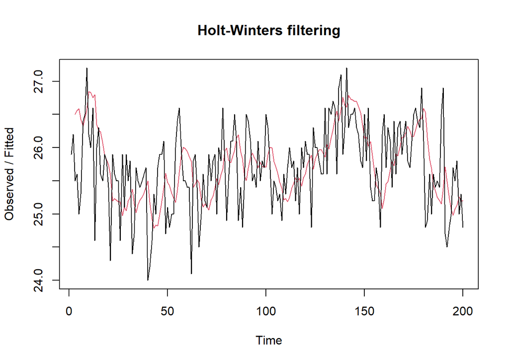

```r
des.1<- HoltWinters(train.ts, gamma = FALSE, beta = 0.2, alpha = 0.2)
plot(des.1)
```

```r
ramalandes1<- forecast(des.1, h=50)
ramalandes1
```

```
##     Point Forecast    Lo 80    Hi 80    Lo 95    Hi 95
## 201       25.09484 24.28434 25.90534 23.85528 26.33439
## 202       25.06775 24.23423 25.90127 23.79300 26.34250
## 203       25.04066 24.17680 25.90452 23.71950 26.36182
## 204       25.01357 24.11162 25.91552 23.63415 26.39299
## 205       24.98648 24.03850 25.93445 23.53668 26.43628
## 206       24.95939 23.95751 25.96127 23.42715 26.49163
## 207       24.93230 23.86884 25.99576 23.30588 26.55871
## 208       24.90521 23.77283 26.03759 23.17338 26.63704
## 209       24.87812 23.66985 26.08639 23.03023 26.72601
## 210       24.85103 23.56032 26.14174 22.87706 26.82500
## 211       24.82394 23.44466 26.20322 22.71451 26.93337
## 212       24.79685 23.32325 26.27045 22.54318 27.05052
## 213       24.76976 23.19647 26.34305 22.36362 27.17590
## 214       24.74267 23.06464 26.42070 22.17634 27.30900
```

[output cut: 36 more lines]

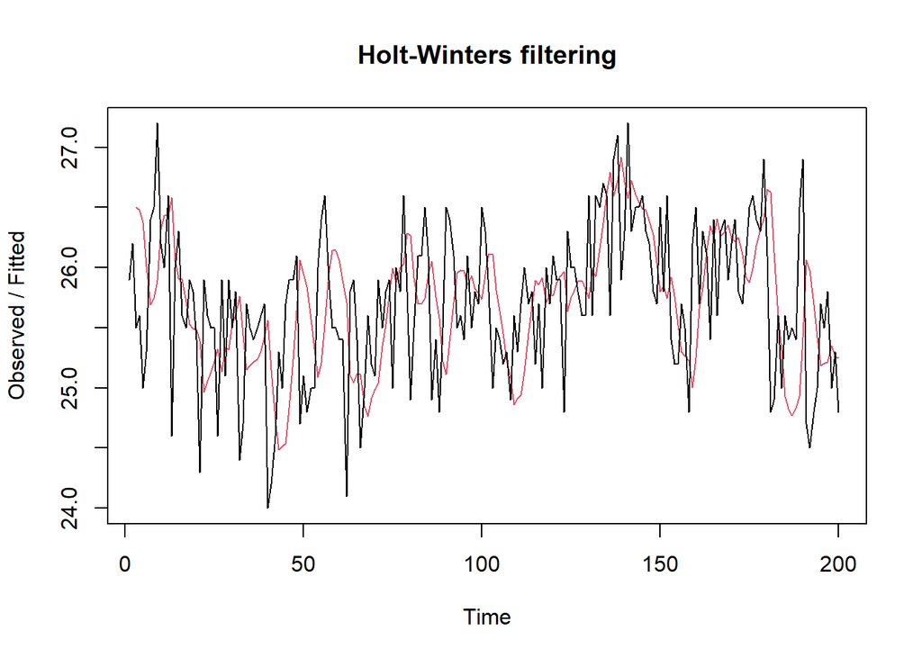

```r
des.2<- HoltWinters(train.ts, gamma = FALSE, beta = 0.6, alpha = 0.2)
plot(des.2)
```

```r
ramalandes2<- forecast(des.2, h=50)
ramalandes2
```

```
##     Point Forecast      Lo 80    Hi 80       Lo 95    Hi 95
## 201       25.08937 24.2151092 25.96363  23.7523028 26.42644
## 202       25.01870 24.1007640 25.93663  23.6148394 26.42256
## 203       24.94802 23.9527465 25.94330  23.4258785 26.47017
## 204       24.87735 23.7681739 25.98653  23.1810114 26.57369
## 205       24.80668 23.5482250 26.06513  22.8820410 26.73131
## 206       24.73600 23.2962550 26.17575  22.5340985 26.93791
## 207       24.66533 23.0161457 26.31451  22.1431206 27.18754
## 208       24.59466 22.7114375 26.47787  21.7145221 27.47479
## 209       24.52398 22.3850574 26.66291  21.2527791 27.79518
## 210       24.45331 22.0393316 26.86729  20.7614496 28.14517
## 211       24.38263 21.6760910 27.08918  20.2433334 28.52194
## 212       24.31196 21.2967834 27.32714  19.7006448 28.92328
## 213       24.24129 20.9025677 27.58001  19.1351563 29.34742
## 214       24.17061 20.4943860 27.84684  18.5483085 29.79292
```

[output cut: 36 more lines]

terdapat beberapa perbedaan dengan Single Exponential Smoothing (SES), salah satunya adalah penambahan parameter gamma untuk memberikan bobot pada trend. Terlihat bahwa pada pemodelan dengan parameter gamma yang lebih tinggi (0.6), hasil forecast lebih sensitif terhadap tren naik turunnya data dibanding ketika parameter gamma yang lebih kecil.

### Visualisasi

#### Ramalan1 (a = 0.2, b = 0.2)

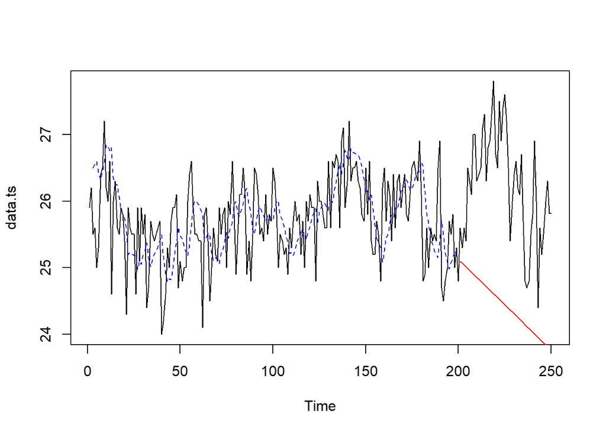

```r
plot(data.ts)
lines(des.1$fitted[,1], lty=2, col="blue")
lines(ramalandes1$mean, col="red")
```

#### Ramalan2 (a = 0.2, b = 0.6)

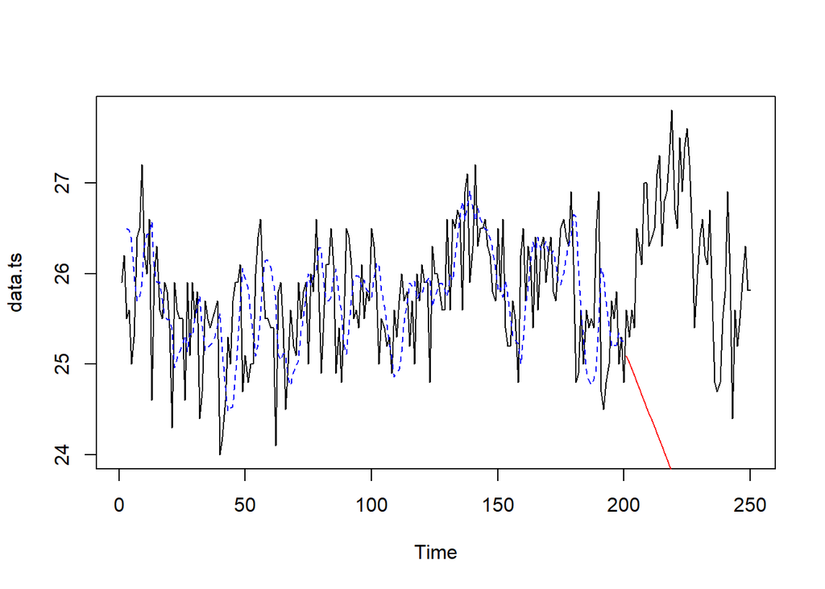

```r
plot(data.ts)
lines(des.2$fitted[,1], lty=2, col="blue")
lines(ramalandes2$mean, col="red")
```

Double Exponential Smoothing cocok digunakan hanya untuk data berupa trend. Dari eksplorasi di awal, dapat diketahui bahwa plot data rataan temperatur Kab. Bogor cenderung menyebar konstan atau stasioner. Karenanya, apabila dilakukan forecasting menggunakan DES, data forecast cenderung menyimpang dari data aktualnya. Pada visualisasi ini, dapat terlihat bahwa data forecast menunjukkan seakan data memiliki trend turun.

## Lambda dan Gamma Optimum

```r
des.opt<- HoltWinters(train.ts, gamma = FALSE)
des.opt
```

```
## Holt-Winters exponential smoothing with trend and without seasonal component.
##
## Call:
## HoltWinters(x = train.ts, gamma = FALSE)
##
## Smoothing parameters:
##  alpha: 0.380026
##  beta : 0.08207183
##  gamma: FALSE
##
## Coefficients:
##          [,1]
## a 25.08352630
## b -0.03616572
```

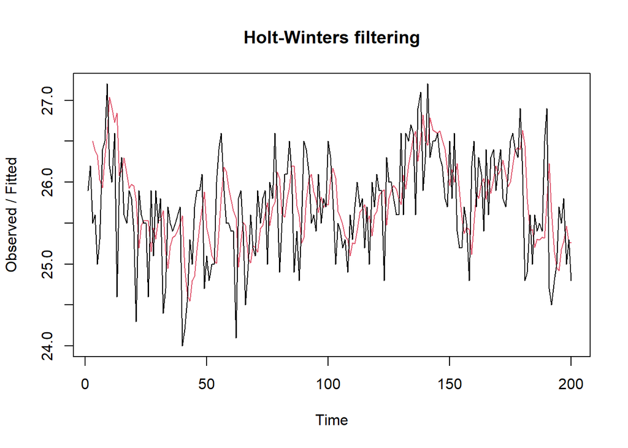

```r
plot(des.opt)
```

```r
ramalandesopt<- forecast(des.opt, h=50)
ramalandesopt
```

```
##     Point Forecast    Lo 80    Hi 80    Lo 95    Hi 95
## 201       25.04736 24.25248 25.84224 23.83170 26.26302
## 202       25.01119 24.15173 25.87066 23.69676 26.32563
## 203       24.97503 24.04641 25.90365 23.55483 26.39523
## 204       24.93886 23.93684 25.94089 23.40640 26.47133
## 205       24.90270 23.82333 25.98207 23.25194 26.55346
## 206       24.86653 23.70612 26.02694 23.09184 26.64122
## 207       24.83037 23.58546 26.07527 22.92645 26.73429
## 208       24.79420 23.46153 26.12687 22.75606 26.83234
## 209       24.75803 23.33451 26.18156 22.58095 26.93512
## 210       24.72187 23.20455 26.23919 22.40133 27.04240
## 211       24.68570 23.07178 26.29962 22.21742 27.15398
## 212       24.64954 22.93632 26.36276 22.02940 27.26968
## 213       24.61337 22.79827 26.42848 21.83741 27.38934
## 214       24.57721 22.65772 26.49670 21.64160 27.51281
```

[output cut: 36 more lines]

Menggunakan fungsi HWopt, ditemukan alpha atau lambda optimal (bobot optimal) untuk data terbaru adalah sebesar 0.38 dan gamma optimalnya sebesar 0.08.

## Akurasi

### AKurasi Data Latih

```r
ssedes.train1<-des.1$SSE
msedes.train1<-ssedes.train1/length(train.ts)
sisaandes1<-ramalandes1$residuals
head(sisaandes1)
```

```
## Time Series:
## Start = 1
## End = 6
## Frequency = 1
## [1]        NA        NA -1.000000 -0.960000 -1.589600 -1.129696
```

```r
mapedes.train1 <- sum(abs(sisaandes1[3:length(train.ts)]/train.ts[3:length(train.ts)])
                      *100)/length(train.ts)

akurasides.1 <- matrix(c(ssedes.train1,msedes.train1,mapedes.train1))
row.names(akurasides.1)<- c("SSE", "MSE", "MAPE")
colnames(akurasides.1) <- c("Akurasi lamda=0.2 dan gamma=0.2")
akurasides.1
```

```
##      Akurasi lamda=0.2 dan gamma=0.2
## SSE                       79.1331494
## MSE                        0.3956657
## MAPE                       1.9684612
```

```r
ssedes.train2<-des.2$SSE
msedes.train2<-ssedes.train2/length(train.ts)
sisaandes2<-ramalandes2$residuals
head(sisaandes2)
```

```
## Time Series:
## Start = 1
## End = 6
## Frequency = 1
## [1]        NA        NA -1.000000 -0.880000 -1.378400 -0.711712
```

```r
mapedes.train2 <- sum(abs(sisaandes2[3:length(train.ts)]/train.ts[3:length(train.ts)])
                      *100)/length(train.ts)

akurasides.2 <- matrix(c(ssedes.train2,msedes.train2,mapedes.train2))
row.names(akurasides.2)<- c("SSE", "MSE", "MAPE")
colnames(akurasides.2) <- c("Akurasi lamda=0.2 dan gamma=0.6")
akurasides.2
```

```
##      Akurasi lamda=0.2 dan gamma=0.6
## SSE                       91.7287612
## MSE                        0.4586438
## MAPE                       2.1032827
```

### Akurasi Data Uji

```r
selisihdes1<-ramalandes1$mean-testing$temp_mean
selisihdes1
```

```
## Time Series:
## Start = 201
## End = 250
## Frequency = 1
##  [1] -0.5051613 -0.2322513 -0.5593412 -0.3864312 -1.5135212 -1.3406112
##  [7] -1.1677012 -2.0947911 -2.1218811 -1.4489711 -1.5760611 -1.7031511
## [13] -2.3302410 -2.5573310 -1.5844210 -2.1115110 -2.2386010 -2.6656909
## [19] -3.1927809 -2.1198709 -1.9469609 -2.9740509 -2.4011408 -2.9282308
## [25] -3.1553208 -2.7824108 -2.1095008 -1.0365907 -1.6636807 -2.0907707
## [31] -2.3178607 -1.9449507 -1.8720406 -2.4991306 -1.5262206 -0.6533106
## [37] -0.5804005 -0.7074905 -1.4345805 -1.7616705 -2.8887605 -2.0158504
## [43] -0.4429404 -1.6700304 -1.2971204 -1.6242104 -2.1513003 -2.4783903
## [49] -2.0183835 -2.0454735
```

```r
SSEtestingdes1<-sum(selisihdes1^2)
MSEtestingdes1<-SSEtestingdes1/length(testing$temp_mean)
MAPEtestingdes1<-sum(abs(selisihdes1/testing$temp_mean)*100)/length(testing$temp_mean)

selisihdes2<-ramalandes2$mean-testing$temp_mean
selisihdes2
```

```
## Time Series:
## Start = 201
## End = 250
## Frequency = 1
##  [1] -0.5106288 -0.2813024 -0.6519761 -0.5226497 -1.6933234 -1.5639971
##  [7] -1.4346707 -2.4053444 -2.4760180 -1.8466917 -2.0173653 -2.1880390
## [13] -2.8587126 -3.1293863 -2.2000600 -2.7707336 -2.9414073 -3.4120809
## [19] -3.9827546 -2.9534282 -2.8241019 -3.8947755 -3.3654492 -3.9361228
## [25] -4.2067965 -3.8774702 -3.2481438 -2.2188175 -2.8894911 -3.3601648
## [31] -3.6308384 -3.3015121 -3.2721857 -3.9428594 -3.0135330 -2.1842067
## [37] -2.1548804 -2.3255540 -3.0962277 -3.4669013 -4.6375750 -3.8082486
## [43] -2.2789223 -3.5495959 -3.2202696 -3.5909433 -4.1616169 -4.5322906
## [49] -4.1158674 -4.1865411
```

```r
SSEtestingdes2<-sum(selisihdes2^2)
MSEtestingdes2<-SSEtestingdes2/length(testing$temp_mean)
MAPEtestingdes2<-sum(abs(selisihdes2/testing$temp_mean)*100)/length(testing$temp_mean)

selisihdesopt<-ramalandesopt$mean-testing$temp_mean
selisihdesopt
```

```
## Time Series:
## Start = 201
## End = 250
## Frequency = 1
##  [1] -0.5526394 -0.2888051 -0.6249709 -0.4611366 -1.5973023 -1.4334680
##  [7] -1.2696337 -2.2057995 -2.2419652 -1.5781309 -1.7142966 -1.8504623
## [13] -2.4866281 -2.7227938 -1.7589595 -2.2951252 -2.4312909 -2.8674566
## [19] -3.4036224 -2.3397881 -2.1759538 -3.2121195 -2.6482852 -3.1844510
## [25] -3.4206167 -3.0567824 -2.3929481 -1.3291138 -1.9652796 -2.4014453
## [31] -2.6376110 -2.2737767 -2.2099424 -2.8461082 -1.8822739 -1.0184396
## [37] -0.9546053 -1.0907710 -1.8269368 -2.1631025 -3.2992682 -2.4354339
## [43] -0.8715996 -2.1077653 -1.7439311 -2.0800968 -2.6162625 -2.9524282
## [49] -2.5014972 -2.5376629
```

```r
SSEtestingdesopt<-sum(selisihdesopt^2)
MSEtestingdesopt<-SSEtestingdesopt/length(testing$temp_mean)
MAPEtestingdesopt<-sum(abs(selisihdesopt/testing$temp_mean)*100)/length(testing$temp_mean)

akurasitestingdes <-
  matrix(c(SSEtestingdes1,MSEtestingdes1,MAPEtestingdes1,SSEtestingdes2,MSEtestingdes2,
           MAPEtestingdes2,SSEtestingdesopt,MSEtestingdesopt,MAPEtestingdesopt),
         nrow=3,ncol=3)
row.names(akurasitestingdes)<- c("SSE", "MSE", "MAPE")
colnames(akurasitestingdes) <- c("des ske1","des ske2","des opt")
akurasitestingdes
```

```
##        des ske1   des ske2    des opt
## SSE  192.081816 471.007373 246.935100
## MSE    3.841636   9.420147   4.938702
## MAPE   6.825380  10.944677   7.859929
```

- $SSE$ merupakan selisih kuadrat dari data uji aktual dengan data yang diperoleh lewat pemulusan. SSE sebesar 192.08, 471.01, dan 246.94 dapat dikatakan bernilai cukup besar apabila dibandingkan dengan skala aktual data (rataan temperatur suhu).Dapat terlihat bahwa SSE pada $\alpha$ = 0.2, $\gamma$ = 0.2 bernilai lebih kecil dibandingkan kedua model lainnya. Ini mengejutkan, karena hipotesis dan harapannya, dengan $\alpha$ dan $\gamma$ minimum, akan diperoleh SSE yang lebih rendah
- $MSE$ merupakan kuadrat tengah dari galat, alias nilai SSE dibagi derajat bebas galat (rataan jumlah kuadrat galat). Nilai MSE sebesar 3.84, 9.42, dan 4.94 mengindikasikan bahwa data forecasting menggunakan DES sedikit meleset dengan data aktualnya (pada data uji). Dapat terlihat bahwa MSE pada $\alpha$ = 0.2, $\gamma$ = 0.2 bernilai lebih kecil dibandingkan kedua model lainnya. Ini mengejutkan, karena hipotesis dan harapannya, dengan $\alpha$ dan $\gamma$ minimum, akan diperoleh SSE yang lebih rendah
- $MAPE$ menunjukkan rataan kesalahan prediksi dalam bentuk persen. Nilai rataan kesalahan prediksi dari 50 data uji bernilai 6.83%, 10.94%, dan 7.86%, semua model masih <10% kecuali model dengan $\alpha$ = 0.2, $\gamma$ = 0.6. Ini mengindikasikan bahwa nilai forecast terhadap data aktual sudah cukup baik, meskipun ada satu model yang >10%. Dapat terlihat bahwa MAPE pada $\alpha$ = 0.2, $\gamma$ = 0.2 bernilai lebih kecil dibandingkan kedua model lainnya. Ini mengejutkan, karena hipotesis dan harapannya, dengan $\alpha$ dan $\gamma$ minimum, akan diperoleh SSE yang lebih rendah

# **PERBANDINGAN SEMUA METODE**

[output not shown]

Pertimbangan untuk menentukan model terbaik dapat ditentukan dengan ukuran akurasi pada data uji. Diharapkannya, skor kesalahan/galat forecast untuk data uji dapat bernilai kecil.Model terbaik untuk melakukan forecasting pada data rataan temperatur Kab.Bogor adalah Single Exponential Smoothing (SES) dengan $\alpha$ optimal sebesar 0,19. Alasannya karena :

- Eksplorasi model pada data rataan temperatur Kab.Bogor cenderung membentuk pola konstan dan atau stasioner. Oleh karena itu, dari keempat metode forecasting, dapat dipersempit pilihannya untuk Single Moving Average (SMA) atau Single Exponential Smoothing (SES). Hal ini dikarenakan, metode DMA dan DES cocoknya hanya untuk data tren, sehingga apabila digunakan untuk data berpola stasioner, tentunya hasil forecastnya akan menyimpang untuk data periode setelah pemulusan terakhir.
- Single Exponential Smoothing (SES) memberikan pembobotan yang berbeda pada tiap periode data. Sedangkan untuk Single Moving Average (SMA), pembobotan untuk setiap periode dalam data adalah konstan/sama. Ini menjadikan metode SES lebih adaptif terhadap perubahan data.
- Terakhir, berdasarkan perhitungan akurasi untuk data uji, SES menghasilkan SSE, MSE, dan MAPE yang lebih kecil dibandingkan SMA. Ini menunjukkan, bahwa kesalahan prediksi SES cenderung lebih kecil dan dengan demikian, data hasil forecast dari metode SES lebih mendekati nilai aktualnya “untuk data uji”.